# Midterm Coursework

RyanYip

# Part 1

## 1a Descriptive statistics

```
## [1] "The Mean,Std Deviation of Democrat is :401.000000,125.175876"
```

```
## [1] "The Mean,Std Deviation of Republicant is :343.000000,49.698466"
```

## 1b Difference in means and confidence interval

According to the data above,I can conclude that this is a mean hypothesis testing Problem for two independent samples.And we use t-test method for this problem.

In statistics, we can define the corresponding null hypothesis (H0) as follow:

- H0: Mean of *Democrat* is equal Mean of *Republicant*
- H1: Mean of *Democrat* is not equal Mean of *Republicant*

And according to the t-test method,we will get the difference in means ,standard error of the difference in means and the confidence intervals of the difference in means.

Accoring the above analysis,we can know

- The difference in means between *registered Democrats* and *registered Republicans* is 58
- The standard error of the difference in means is 23.4449306
- The 95% confidence intervals of the difference in means is (11.1633668,104.8366332)
- The 99% confidence intervals of the difference in means is (-4.2428758,120.2428758)

## 1c Summary

And we will test which is more use the t-test again bellow.

```r
t.test(Democrat,Republicant,alternative = "greater",conf.level = 0.95)
```

```
##
##  Welch Two Sample t-test
##
## data:  Democrat and Republicant
## t = 2.4739, df = 41.844, p-value = 0.008754
## alternative hypothesis: true difference in means is greater than 0
## 95 percent confidence interval:
##  18.56342      Inf
## sample estimates:
## mean of x mean of y
##       401       343
```

Based on the result of t-test with alternative hypothesis(Democrat > Republicant),the p-value is less than 0.05,so reject the null hypothesis,that is,in statistics means,we have 95% confidence to believe that the Democrathas more support.

# Part 2

### Read Data

```
## 'data.frame':    376 obs. of  9 variables:
##  $ code           : int  416 417 267 92 98 423 418 268 219 160 ...
##  $ country        : int  2 2 1 1 1 2 2 1 1 1 ...
##  $ pop_density    : int  2 1 2 1 1 1 1 2 2 1 ...
##  $ pmdeaths_total : num  20484 15328 14930 16548 15268 ...
##  $ pmdeaths_female: num  16368 13123 11442 13522 12273 ...
##  $ pmdeaths_male  : num  24600 17533 18418 19574 18262 ...
##  $ mean_income    : num  36950 37008 28537 31561 31396 ...
##  $ edu_level3     : num  0.0964 0.1016 0.1118 0.1152 0.1199 ...
##  $ edu_level4     : num  0.332 0.27 0.22 0.228 0.232 ...
##  - attr(*, "na.action")=Class 'omit'  Named int [1:2] 113 155
##   .. ..- attr(*, "names")= chr [1:2] "113" "155"
```

## 2a Descriptive Statistics

We will use the mean ,median,min and max to measure the central tendency of variable,use the variance as measures of the dispersion following

```
## [1] "The variable edu_level3 --- mean:0.120286,median:0.119151,min:0.075525,max:0.192466,std:0.017279"
```

```
## [1] "The variable edu_level4 --- mean:0.267991,median:0.256720,min:0.142148,max:0.535734,std:0.073995"
```

```
## [1] "The variable pop_density --- mean:1.622340,median:1.500000,min:1.000000,max:3.000000,std:0.693537"
```

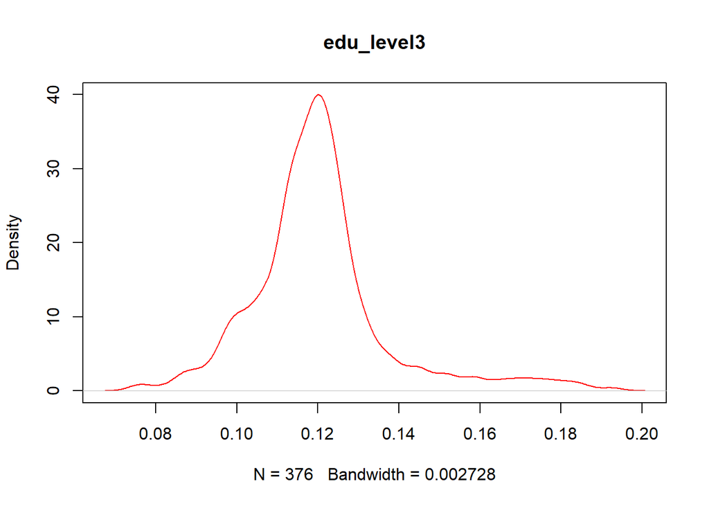

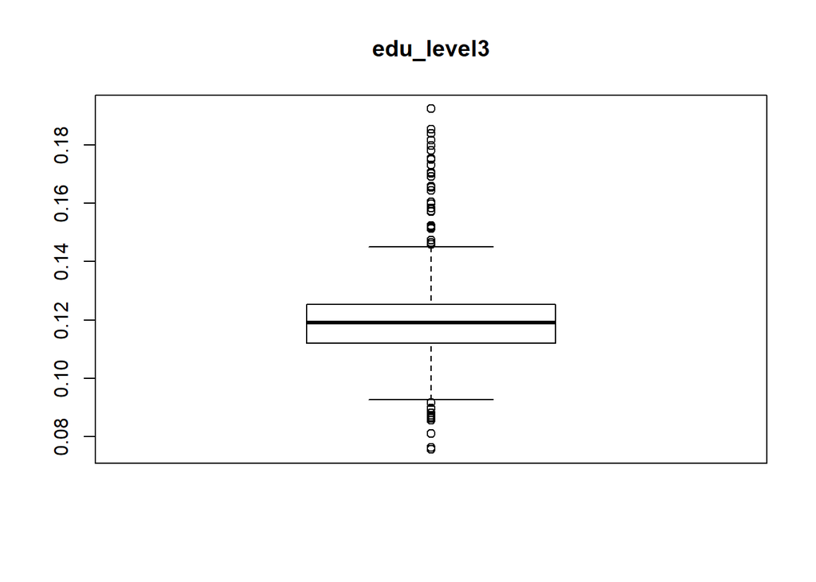

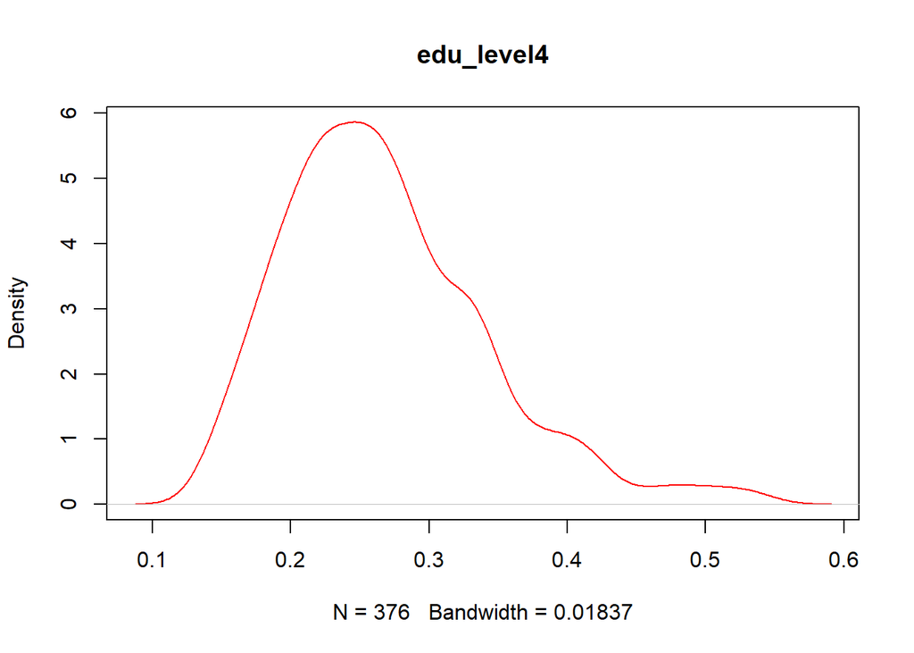

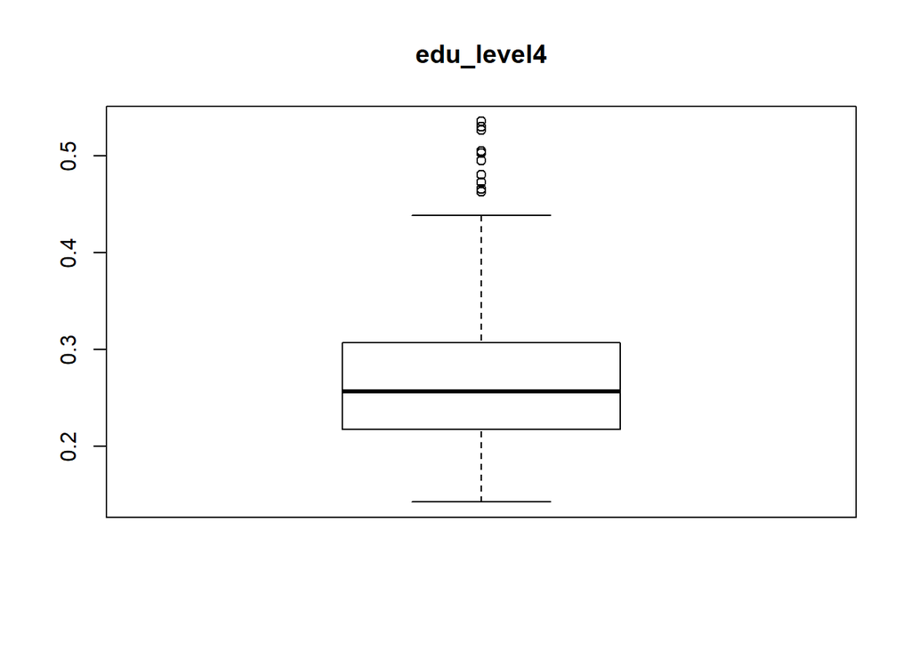

```
## pop_density
##         1         2         3
## 0.5000000 0.3776596 0.1223404
```

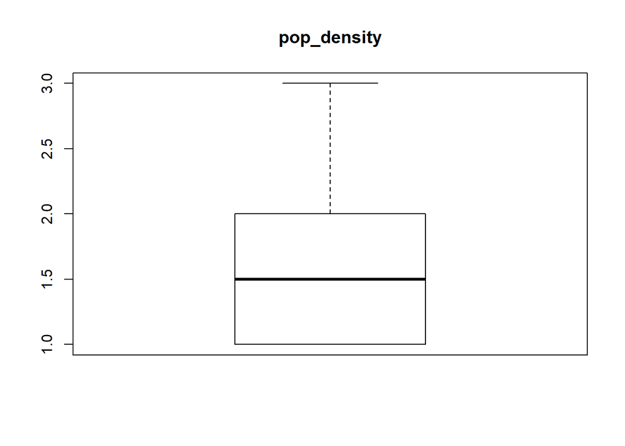

According to the variable describe and the visualization,the variances in *edu_level3* and *edu_level4* is small,which mean distribution is relatively stable.And the mean and median are almost similiar,which indicate they both have central trendancy.In variable *pop_density*,we can the data mainly concentrate in 1 and 2,and the variance is relativey large.Above plot only show them in visualization.

## 2b Visualization

- 2b.1) Scatterplot

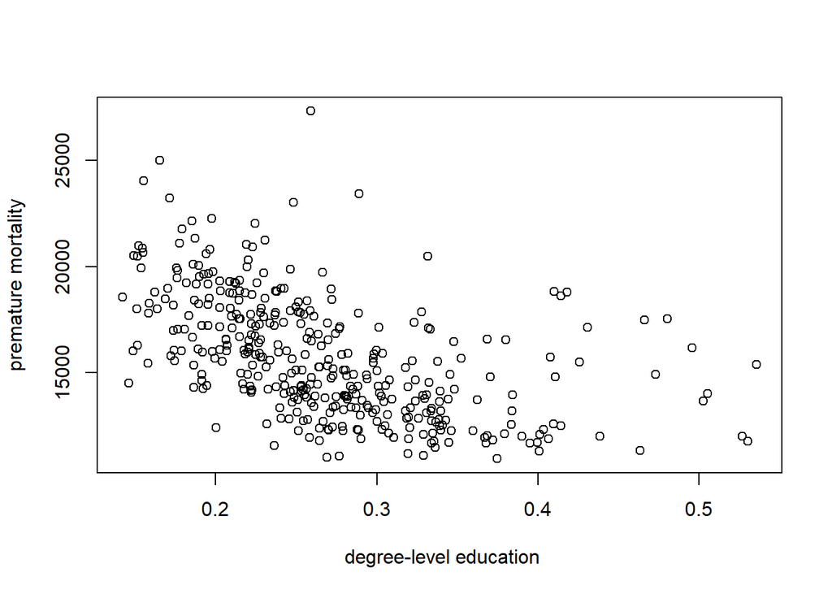

According to the scatterplot,we can know that *degree-level education* has a negative linear correlation with *premature mortality*,which means that when *degree-level education* increase,and premature mortality will decrease.And the correlation between they is -0.5198572,which can comfirm this.

- box plot

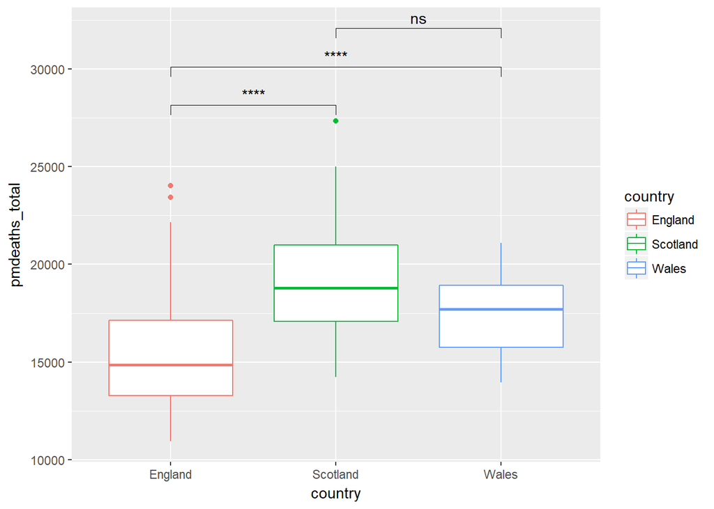

The boxplot tells that the *premature mortality* in Scotland is the most highest,and Wales secondly,the England is the most smallest.And difference in Eangland and Scotland,England and Wales is sigficant.

## 2c Difference in Means

```
## The mean difference between premature mortality among men and women in Great Britain is : 6069.719
```

```
## Conduct t-test:
```

```
##
##  Welch Two Sample t-test
##
## data:  pmdata$pmdeaths_male and pmdata$pmdeaths_female
## t = 28.245, df = 647.34, p-value < 2.2e-16
## alternative hypothesis: true difference in means is greater than 0
## 95 percent confidence interval:
##  5715.739      Inf
## sample estimates:
## mean of x mean of y
##  18763.22  12693.50
```

In the test,I use the alternative hypothesis is : male is greater than femele.According to the t-test result,we know that the p-value is smaller than 0.05,which means that we has 95% confidence to believe thaht *premature mortality* among men and women in Great Britain is different in statistics.In fact ,it is consistent with commen sense,in many surveys, men’s lives are indeed shorter than women’s.

## 2d Linear Regression

```
##
## Call:
## lm(formula = pmdeaths_total ~ mean_income, data = pmdata)
##
## Residuals:
##     Min      1Q  Median      3Q     Max
## -5589.1 -1838.1  -389.1  1382.8 11010.0
##
## Coefficients:
##               Estimate Std. Error t value Pr(>|t|)
## (Intercept)  2.107e+04  5.147e+02   40.94   <2e-16 ***
## mean_income -1.590e-01  1.484e-02  -10.71   <2e-16 ***
## ---
## Signif. codes:  0 '***' 0.001 '**' 0.01 '*' 0.05 '.' 0.1 ' ' 1
##
## Residual standard error: 2475 on 374 degrees of freedom
## Multiple R-squared:  0.2348, Adjusted R-squared:  0.2327
## F-statistic: 114.8 on 1 and 374 DF,  p-value: < 2.2e-16
```

Accoring to the model summary,the coefficient of *mean_income* is -0.1589698,and the test is sinificant,which indicate that mean_income has a negative effect on *pmdeaths_total*,when *mean_income* add one unit,*pmdeaths_total* will substract about 0.16 unit.And it is credible in statistics based on test.

The *R square* of mdoel is about 0.23 ,it is a litte smaller in statistics,which means that the predictor *mean_income* can explain 23% message in *pmdeaths_total*,and it represent the goodness of fit for model.So,only use *mean_income* as predictor is not enough to explain the model I think.

# Part 3